# US Flights 2018 Dataset

## by Islam M. Saad

## Preliminary Wrangling

```python
# import all packages and set plots to be embedded inline
import numpy as np
import pandas as pd
import matplotlib.pyplot as plt
import seaborn as sb

%matplotlib inline
```

> Load in the dataset and describe its properties

```python
df = pd.read_csv("2018_full.csv")
```

```python
# high-level overview of data shape and composition
print(df.shape)
print(df.dtypes)
df.head(3)
```

```
(7213446, 28)
FL_DATE                 object
OP_CARRIER              object
OP_CARRIER_FL_NUM        int64
ORIGIN                  object
DEST                    object
CRS_DEP_TIME             int64
DEP_TIME               float64
DEP_DELAY              float64
TAXI_OUT               float64
WHEELS_OFF             float64
WHEELS_ON              float64
TAXI_IN                float64
CRS_ARR_TIME             int64
ARR_TIME               float64
ARR_DELAY              float64
CANCELLED              float64
CANCELLATION_CODE       object
DIVERTED               float64
CRS_ELAPSED_TIME       float64
ACTUAL_ELAPSED_TIME    float64
AIR_TIME               float64
DISTANCE               float64
CARRIER_DELAY          float64
WEATHER_DELAY          float64
NAS_DELAY              float64
SECURITY_DELAY         float64
LATE_AIRCRAFT_DELAY    float64
Unnamed: 27            float64
dtype: object
```

|  | FL_DATE | OP_CARRIER | OP_CARRIER_FL_NUM | ORIGIN | DEST | CRS_DEP_TIME | DEP_TIME | DEP_DELAY | TAXI_OUT | WHEELS_OFF | ... | CRS_ELAPSED_TIME | ACTUAL_ELAPSED_TIME | AIR_TIME | DISTANCE | CARRIER_DELAY | WEATHER_DELAY | NAS_DELAY | SECURITY_DELAY | LATE_AIRCRAFT_DELAY | Unnamed: 27 |
| --- | --- | --- | --- | --- | --- | --- | --- | --- | --- | --- | --- | --- | --- | --- | --- | --- | --- | --- | --- | --- | --- |
| 0 | 2018-01-01 | UA | 2429 | EWR | DEN | 1517 | 1512.0 | -5.0 | 15.0 | 1527.0 | ... | 268.0 | 250.0 | 225.0 | 1605.0 | NaN | NaN | NaN | NaN | NaN | NaN |
| 1 | 2018-01-01 | UA | 2427 | LAS | SFO | 1115 | 1107.0 | -8.0 | 11.0 | 1118.0 | ... | 99.0 | 83.0 | 65.0 | 414.0 | NaN | NaN | NaN | NaN | NaN | NaN |
| 2 | 2018-01-01 | UA | 2426 | SNA | DEN | 1335 | 1330.0 | -5.0 | 15.0 | 1345.0 | ... | 134.0 | 126.0 | 106.0 | 846.0 | NaN | NaN | NaN | NaN | NaN | NaN |

3 rows × 28 columns

### What is the structure of your dataset?

> 7.2 million records dataset and we will use random sample of 10% (about 720K) records in order to ease and agile the analysis.

### What is/are the main feature(s) of interest in your dataset?

> Arrival Delay, Departure Delay

### What features in the dataset do you think will help support your investigation into your feature(s) of interest?

> OP_CARRIER, Actual Elapsed Time, ORIGIN Airports, DEST Airports, Distance, DATE, Arrival Time, Departure Time.

Selecting 10% records of the Dataset

```python
df = df.sample(frac=0.1, replace=True, random_state=1)
# high-level overview of data shape and composition
print(df.shape)
print(df.dtypes)
df.head(3)
```

```
(721345, 28)
FL_DATE                 object
OP_CARRIER              object
OP_CARRIER_FL_NUM        int64
ORIGIN                  object
DEST                    object
CRS_DEP_TIME             int64
DEP_TIME               float64
DEP_DELAY              float64
TAXI_OUT               float64
WHEELS_OFF             float64
WHEELS_ON              float64
TAXI_IN                float64
CRS_ARR_TIME             int64
ARR_TIME               float64
ARR_DELAY              float64
CANCELLED              float64
CANCELLATION_CODE       object
DIVERTED               float64
CRS_ELAPSED_TIME       float64
ACTUAL_ELAPSED_TIME    float64
AIR_TIME               float64
DISTANCE               float64
CARRIER_DELAY          float64
WEATHER_DELAY          float64
NAS_DELAY              float64
SECURITY_DELAY         float64
LATE_AIRCRAFT_DELAY    float64
Unnamed: 27            float64
dtype: object
```

|  | FL_DATE | OP_CARRIER | OP_CARRIER_FL_NUM | ORIGIN | DEST | CRS_DEP_TIME | DEP_TIME | DEP_DELAY | TAXI_OUT | WHEELS_OFF | ... | CRS_ELAPSED_TIME | ACTUAL_ELAPSED_TIME | AIR_TIME | DISTANCE | CARRIER_DELAY | WEATHER_DELAY | NAS_DELAY | SECURITY_DELAY | LATE_AIRCRAFT_DELAY | Unnamed: 27 |
| --- | --- | --- | --- | --- | --- | --- | --- | --- | --- | --- | --- | --- | --- | --- | --- | --- | --- | --- | --- | --- | --- |
| 4322341 | 2018-08-07 | WN | 1237 | TPA | LGA | 1425 | 1510.0 | 45.0 | 9.0 | 1519.0 | ... | 160.0 | NaN | NaN | 1010.0 | NaN | NaN | NaN | NaN | NaN | NaN |
| 4686059 | 2018-08-24 | NK | 805 | ATL | LAS | 1810 | 1804.0 | -6.0 | 13.0 | 1817.0 | ... | 248.0 | 239.0 | 222.0 | 1747.0 | NaN | NaN | NaN | NaN | NaN | NaN |
| 6762380 | 2018-12-08 | WN | 4344 | TPA | DAL | 935 | 937.0 | 2.0 | 14.0 | 951.0 | ... | 160.0 | 155.0 | 137.0 | 917.0 | NaN | NaN | NaN | NaN | NaN | NaN |

3 rows × 28 columns

```python
# Check unique values in OP_CARRIER (airline) column
df.OP_CARRIER.unique() , df.OP_CARRIER.nunique()
```

```
(array(['WN', 'NK', 'AA', 'DL', 'YX', 'HA', 'F9', 'OH', 'EV', 'UA', 'MQ',
        'G4', 'OO', 'AS', '9E', 'B6', 'YV', 'VX'], dtype=object), 18)
```

```python
# Adding airline company names
# Source: https://en.wikipedia.org/wiki/List_of_airlines_of_the_United_States
df['OP_CARRIER_NAME']=df['OP_CARRIER'].replace({
    'UA':'United Airlines',
    'AS':'Alaska Airlines',
    '9E':'Endeavor Air',
    'B6':'JetBlue Airways',
    'EV':'ExpressJet',
    'F9':'Frontier Airlines',
    'G4':'Allegiant Air',
    'HA':'Hawaiian Airlines',
    'MQ':'Envoy Air',
    'NK':'Spirit Airlines',
    'OH':'PSA Airlines',
    'OO':'SkyWest Airlines',
    'VX':'Virgin America',
    'WN':'Southwest Airlines',
    'YV':'Mesa Airline',
    'YX':'Republic Airways',
    'AA':'American Airlines',
    'DL':'Delta Airlines'
},inplace=False)
df.tail(3)
```

|  | FL_DATE | OP_CARRIER | OP_CARRIER_FL_NUM | ORIGIN | DEST | CRS_DEP_TIME | DEP_TIME | DEP_DELAY | TAXI_OUT | WHEELS_OFF | ... | ACTUAL_ELAPSED_TIME | AIR_TIME | DISTANCE | CARRIER_DELAY | WEATHER_DELAY | NAS_DELAY | SECURITY_DELAY | LATE_AIRCRAFT_DELAY | Unnamed: 27 | OP_CARRIER_NAME |
| --- | --- | --- | --- | --- | --- | --- | --- | --- | --- | --- | --- | --- | --- | --- | --- | --- | --- | --- | --- | --- | --- |
| 2141629 | 2018-04-23 | UA | 1451 | LAX | ORD | 1840 | 1827.0 | -13.0 | 19.0 | 1846.0 | ... | 237.0 | 211.0 | 1744.0 | NaN | NaN | NaN | NaN | NaN | NaN | United Airlines |
| 5120886 | 2018-09-16 | AS | 346 | SEA | SJC | 745 | 738.0 | -7.0 | 16.0 | 754.0 | ... | 127.0 | 104.0 | 696.0 | NaN | NaN | NaN | NaN | NaN | NaN | Alaska Airlines |
| 653521 | 2018-02-05 | YX | 4643 | BNA | CLT | 1003 | 1005.0 | 2.0 | 19.0 | 1024.0 | ... | 86.0 | 51.0 | 328.0 | NaN | NaN | NaN | NaN | NaN | NaN | Republic Airways |

3 rows × 29 columns

# Cleaning Dataset

We will find out not cancelled flights to be only included in df

```python
#we will make new df with cancelled equals 0
df['CANCELLED'].value_counts()
```

```
0.0    709718
1.0     11627
Name: CANCELLED, dtype: int64
```

Then we have 11627 cancelled flights from 10% sample of 7.2Million Records and then we will drop it as we only study delay of flights.

```python
#creat new data frame called flights with Non-cancelled flights 7,096,862 observations
flights = df.query("CANCELLED==0")
flights.shape
```

```
(709718, 29)
```

```python
#cleaning our dataset by finding out duplicated rows
flights.duplicated().sum()
```

```
34387
```

```python
#cleaning our dataset by drop duplicated 34387 rows
flights=flights.drop_duplicates()
flights.shape
```

```
(675331, 29)
```

We found 34387 duplicated rows in flights dataframe and after drop it, we have 675331 records at our 10% sample.

Thirdly, We search for missing values in order to clean flights dataset

```python
#find out missing values in order to clean flights dataset
flights.isna().sum()
```

```
FL_DATE                     0
OP_CARRIER                  0
OP_CARRIER_FL_NUM           0
ORIGIN                      0
DEST                        0
CRS_DEP_TIME                0
DEP_TIME                    0
DEP_DELAY                 458
TAXI_OUT                    0
WHEELS_OFF                  0
WHEELS_ON                 238
TAXI_IN                   238
CRS_ARR_TIME                0
ARR_TIME                  238
ARR_DELAY                2014
CANCELLED                   0
CANCELLATION_CODE      675331
DIVERTED                    0
CRS_ELAPSED_TIME            0
ACTUAL_ELAPSED_TIME      1757
AIR_TIME                 1757
DISTANCE                    0
CARRIER_DELAY          546461
WEATHER_DELAY          546461
NAS_DELAY              546461
SECURITY_DELAY         546461
LATE_AIRCRAFT_DELAY    546461
Unnamed: 27            675331
OP_CARRIER_NAME             0
dtype: int64
```

# Contniue - Cleaning Dataset

We have important columns having missing values such as: 'DEP_DELAY','WHEELS_ON','TAXI_IN','ARR_TIME','ARR_DELAY','CRS_ELAPSED_TIME','ACTUAL_ELAPSED_TIME','AIR_TIME' we will delete only rows with missing data on those columns Additionally, we have columns have huge misisng data but we don't need to lose all these rows such as: 'SECURITY_DELAY','NAS_DELAY','LATE_AIRCRAFT_DELAY','WEATHER_DELAY','CARRIER_DELAY' because those rows can reflect the reason for delay as we can expecte right now. Furthermore, 'CANCELLED','CANCELLATION_CODE', 'Unnamed' have approximately no data to help, and then we will drop them.

```python
flights.drop(['CANCELLED','CANCELLATION_CODE','Unnamed: 27'],axis='columns', inplace=True)
flights.shape
```

```
(675331, 26)
```

```python
flights.dropna(subset=['DEP_DELAY','WHEELS_ON','TAXI_IN','ARR_TIME','ARR_DELAY','CRS_ELAPSED_TIME','ACTUAL_ELAPSED_TIME','AIR_TIME'],inplace = True)
flights.shape
```

```
(672866, 26)
```

```python
#Check that 'SECURITY_DELAY','NAS_DELAY','LATE_AIRCRAFT_DELAY','WEATHER_DELAY','CARRIER_DELAY' only
#have missing values and Now flights dataset is cleaned and ready for Exploratory stage
flights.isna().sum()
```

```
FL_DATE                     0
OP_CARRIER                  0
OP_CARRIER_FL_NUM           0
ORIGIN                      0
DEST                        0
CRS_DEP_TIME                0
DEP_TIME                    0
DEP_DELAY                   0
TAXI_OUT                    0
WHEELS_OFF                  0
WHEELS_ON                   0
TAXI_IN                     0
CRS_ARR_TIME                0
ARR_TIME                    0
ARR_DELAY                   0
DIVERTED                    0
CRS_ELAPSED_TIME            0
ACTUAL_ELAPSED_TIME         0
AIR_TIME                    0
DISTANCE                    0
CARRIER_DELAY          544020
WEATHER_DELAY          544020
NAS_DELAY              544020
SECURITY_DELAY         544020
LATE_AIRCRAFT_DELAY    544020
OP_CARRIER_NAME             0
dtype: int64
```

```python
# Convert string to DateTime
pd.to_datetime(flights.FL_DATE)
# Month variable
flights['FL_DATE_month'] = pd.to_datetime(flights['FL_DATE']).dt.month
# Weekday variable
flights['FL_DATE_weekday'] = pd.to_datetime(flights['FL_DATE']).dt.weekday_name
```

```python
# ARRIVAL DELAY Minutes to hours
flights['ARR_DELAY_HR'] = flights['ARR_DELAY'] / 60
# DEPARTURE DELAY Minutes to hours
flights['DEP_DELAY_HR'] = flights['DEP_DELAY'] / 60
```

```python
flights.shape
```

```
(672866, 30)
```

## Univariate Exploration

# Departure Delay & Arrival Delay

```python
# Arrival delay data (in minutes)
flights.ARR_DELAY.head(10)
```

```
4686059   -15.0
6762380    -3.0
3937352    -6.0
491263     -6.0
5030793    -4.0
6662859   -14.0
4267653    86.0
1166159    -6.0
2326672    16.0
413825    -15.0
Name: ARR_DELAY, dtype: float64
```

We find out Arrival Delay takes negative sign when flight arrives early. And it takes positive values when delayed flights arrive. Right now, we will compute how many flights were delayed in arrival time.

```python
flights["ARR_DELAY_FLAG"] = np.where(flights["ARR_DELAY"]>0,'Delayed','On-Time')
flights.head()
```

|  | FL_DATE | OP_CARRIER | OP_CARRIER_FL_NUM | ORIGIN | DEST | CRS_DEP_TIME | DEP_TIME | DEP_DELAY | TAXI_OUT | WHEELS_OFF | ... | WEATHER_DELAY | NAS_DELAY | SECURITY_DELAY | LATE_AIRCRAFT_DELAY | OP_CARRIER_NAME | FL_DATE_month | FL_DATE_weekday | ARR_DELAY_HR | DEP_DELAY_HR | ARR_DELAY_FLAG |
| --- | --- | --- | --- | --- | --- | --- | --- | --- | --- | --- | --- | --- | --- | --- | --- | --- | --- | --- | --- | --- | --- |
| 4686059 | 2018-08-24 | NK | 805 | ATL | LAS | 1810 | 1804.0 | -6.0 | 13.0 | 1817.0 | ... | NaN | NaN | NaN | NaN | Spirit Airlines | 8 | Friday | -0.250000 | -0.100000 | On-Time |
| 6762380 | 2018-12-08 | WN | 4344 | TPA | DAL | 935 | 937.0 | 2.0 | 14.0 | 951.0 | ... | NaN | NaN | NaN | NaN | Southwest Airlines | 12 | Saturday | -0.050000 | 0.033333 | On-Time |
| 3937352 | 2018-07-20 | AA | 1561 | DFW | MSY | 1455 | 1450.0 | -5.0 | 13.0 | 1503.0 | ... | NaN | NaN | NaN | NaN | American Airlines | 7 | Friday | -0.100000 | -0.083333 | On-Time |
| 491263 | 2018-01-27 | AA | 2058 | CLT | EWR | 1830 | 1829.0 | -1.0 | 33.0 | 1902.0 | ... | NaN | NaN | NaN | NaN | American Airlines | 1 | Saturday | -0.100000 | -0.016667 | On-Time |
| 5030793 | 2018-09-11 | DL | 2586 | MCO | ATL | 1625 | 1622.0 | -3.0 | 21.0 | 1643.0 | ... | NaN | NaN | NaN | NaN | Delta Airlines | 9 | Tuesday | -0.066667 | -0.050000 | On-Time |

5 rows × 31 columns

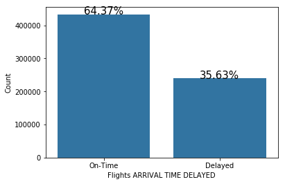

```python
# univariate plots of ARRIVAL DELAY
ARR_order = flights['ARR_DELAY_FLAG'].value_counts().index
base_color = sb.color_palette()[0]
sb.countplot(data=flights, x='ARR_DELAY_FLAG', color=base_color, order=ARR_order);
plt.xticks(rotation=0);
# Recalculating the cut_counts
ARR_DELAY_counts = flights['ARR_DELAY_FLAG'].value_counts()
# Returns the sum of all not-null values in `cut` column
n_flights = flights['ARR_DELAY_FLAG'].value_counts().sum()
# get the current tick locations and labels
locs, labels = plt.xticks(rotation=0)

# loop through each pair of locations and labels
for loc, label in zip(locs, labels):

    # get the text property for the label to get the correct count
    count = ARR_DELAY_counts[label.get_text()]
    pct_string = '{:0.2f}%'.format(100*count/n_flights)

    # print the annotation just below the top of the bar
    plt.text(loc, count+2, pct_string, ha = 'center', color = 'black',fontsize=15, verticalalignment='baseline')
plt.xlabel('Flights ARRIVAL TIME DELAYED');
plt.ylabel('Count');
from matplotlib import rcParams
# Specify the figure size in inches, for both X, and Y axes
rcParams['figure.figsize'] =4,4
```

```python
flights['ARR_DELAY_FLAG'].value_counts()
```

```
On-Time    433128
Delayed    239738
Name: ARR_DELAY_FLAG, dtype: int64
```

- We can conclude that we have 239,738 delayed flights due to Arrival delay which is 35.63% of total flights in our sample

```python
flights["DEP_DELAY_FLAG"] = np.where(flights["DEP_DELAY"]>0,'Delayed','On-Time')
```

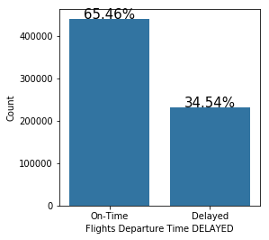

```python
# univariate plots of DEP DELAY
DEP_order = flights['DEP_DELAY_FLAG'].value_counts().index
base_color = sb.color_palette()[0]
sb.countplot(data=flights, x='DEP_DELAY_FLAG', color=base_color, order=DEP_order);
plt.xticks(rotation=0);
# Recalculating the cut_counts
DEP_DELAY_counts = flights['DEP_DELAY_FLAG'].value_counts()
# Returns the sum of all not-null values in `cut` column
n_flights = flights['DEP_DELAY_FLAG'].value_counts().sum()
# get the current tick locations and labels
locs, labels = plt.xticks(rotation=0)

# loop through each pair of locations and labels
for loc, label in zip(locs, labels):

    # get the text property for the label to get the correct count
    count = DEP_DELAY_counts[label.get_text()]
    pct_string = '{:0.2f}%'.format(100*count/n_flights)

    # print the annotation just below the top of the bar
    plt.text(loc, count+2, pct_string, ha = 'center', color = 'black',fontsize=15, verticalalignment='baseline')
plt.xlabel('Flights Departure Time DELAYED');
plt.ylabel('Count');
from matplotlib import rcParams
# Specify the figure size in inches, for both X, and Y axes
rcParams['figure.figsize'] =4,4
```

```python
flights['DEP_DELAY_FLAG'].value_counts()
```

```
On-Time    440481
Delayed    232385
Name: DEP_DELAY_FLAG, dtype: int64
```

# OP_CARRIER Flights Percentage

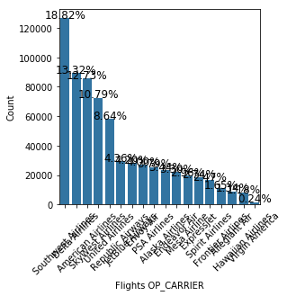

```python
# univariate plots of OP_CARRIER

DEP_order = flights['OP_CARRIER_NAME'].value_counts().index
base_color = sb.color_palette()[0]
sb.countplot(data=flights, x='OP_CARRIER_NAME', color=base_color, order=DEP_order);
plt.xticks(rotation=0);
# Recalculating the cut_counts
DEP_DELAY_counts = flights['OP_CARRIER_NAME'].value_counts()
# Returns the sum of all not-null values in `cut` column
n_flights = flights['OP_CARRIER_NAME'].value_counts().sum()
# get the current tick locations and labels
locs, labels = plt.xticks(rotation=45)

# loop through each pair of locations and labels
for loc, label in zip(locs, labels):

    # get the text property for the label to get the correct count
    count = DEP_DELAY_counts[label.get_text()]
    pct_string = '{:0.2f}%'.format(100*count/n_flights)

    # print the annotation just below the top of the bar
    plt.text(loc, count+2, pct_string, ha = 'center', color = 'black',fontsize=12, verticalalignment='baseline')
plt.xlabel('Flights OP_CARRIER');
plt.ylabel('Count');
from matplotlib import rcParams
# Specify the figure size in inches, for both X, and Y axes
rcParams['figure.figsize'] =20,6
```

- We can conclude that Southwest Airlines is the largest number of flights in 2018 by 18% of the total flights and we can explore that Delta Airlines, American Airlines, SkyWest Airlines, United Airlines took about 45% of flights. Therefore, we can see that Top 5 Airlines carriers took about 63% of US flights in 2018. Then we will focus on Top 5 in later analysis.

# ORIGIN & DEST (Flights Percentage)

```python
flights['ORIGIN'].value_counts()
```

```
ATL    36585
ORD    30955
DFW    26125
DEN    22254
CLT    21804
LAX    20751
SFO    16445
PHX    16276
IAH    16226
LGA    15547
LAS    15102
DTW    14829
MSP    14745
BOS    13577
MCO    13222
SEA    13212
EWR    13209
DCA    12150
JFK    12026
PHL    10818
SLC    10749
BWI    10013
FLL     9299
SAN     8504
MIA     8241
MDW     8089
TPA     7075
BNA     7019
DAL     6689
IAD     6438
       ...
LBF       46
PVU       45
CNY       38
ELM       36
OTH       32
GUC       30
PSM       27
SPN       25
VEL       20
PRC       20
WYS       19
FLO       16
SMX       15
EAR       14
PPG       13
DRT       12
OGS       12
DLG       12
ADK       12
STC       12
MMH       11
BKG       10
OWB       10
HGR        9
CYS        8
AKN        7
OGD        7
GST        7
IFP        5
HYA        5
Name: ORIGIN, Length: 356, dtype: int64
```

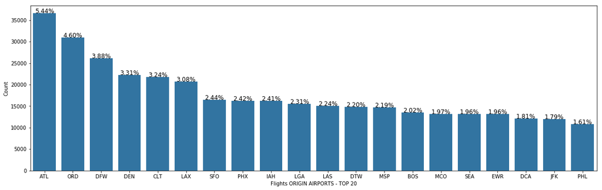

```python
# univariate plots of ORIGIN
ORIGIN_order = flights['ORIGIN'].value_counts()[:20].index
base_color = sb.color_palette()[0]
sb.countplot(data=flights, x='ORIGIN', color=base_color, order=ORIGIN_order);
plt.xticks(rotation=0);
# Recalculating the cut_counts
DEP_DELAY_counts = flights['ORIGIN'].value_counts()
# Returns the sum of all not-null values in `cut` column
n_flights = flights['ORIGIN'].value_counts().sum()
# get the current tick locations and labels
locs, labels = plt.xticks(rotation=0)

# loop through each pair of locations and labels
for loc, label in zip(locs, labels):

    # get the text property for the label to get the correct count
    count = DEP_DELAY_counts[label.get_text()]
    pct_string = '{:0.2f}%'.format(100*count/n_flights)

    # print the annotation just below the top of the bar
    plt.text(loc, count+2, pct_string, ha = 'center', color = 'black',fontsize=12, verticalalignment='baseline')
plt.xlabel('Flights ORIGIN AIRPORTS - TOP 20');
plt.ylabel('Count');
from matplotlib import rcParams
# Specify the figure size in inches, for both X, and Y axes
rcParams['figure.figsize'] =18,5
```

- As we have 356 ORIGIN airports then we will graph the top 20 and then we will focus on top 6

```python
flights['DEST'].value_counts()
```

```
ATL    36561
ORD    30783
DFW    25836
DEN    22116
CLT    21625
LAX    20669
SFO    16495
PHX    16350
IAH    16134
LGA    15698
LAS    15309
MSP    14974
DTW    14890
BOS    13575
SEA    13314
EWR    13195
MCO    12791
DCA    12201
JFK    11962
PHL    10882
SLC    10780
BWI     9976
FLL     9049
SAN     8578
MIA     8212
MDW     7929
BNA     7056
TPA     7041
DAL     6605
IAD     6451
       ...
CNY       41
MVY       40
OTH       38
ELM       30
PSM       28
SPN       28
PRC       23
GUC       22
SMX       19
EAR       19
HGR       18
VEL       17
WYS       16
MMH       16
FLO       15
OGD       14
STC       12
OGS       12
DLG       11
DRT       10
HYA       10
OWB        8
PPG        8
BKG        7
ADK        7
CYS        6
IFP        6
GST        5
AKN        5
ART        2
Name: DEST, Length: 357, dtype: int64
```

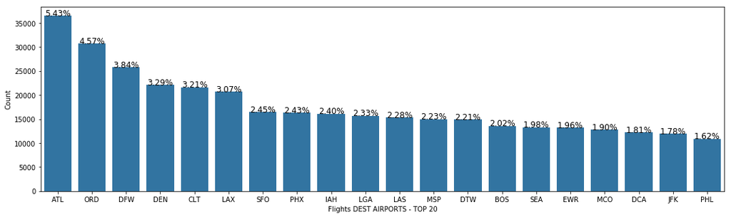

```python
# univariate plots of DEST
DEST_order = flights['DEST'].value_counts()[:20].index
base_color = sb.color_palette()[0]
sb.countplot(data=flights, x='DEST', color=base_color, order=DEST_order);
plt.xticks(rotation=0);
# Recalculating the cut_counts
DEP_DELAY_counts = flights['DEST'].value_counts()
# Returns the sum of all not-null values in `cut` column
n_flights = flights['DEST'].value_counts().sum()
# get the current tick locations and labels
locs, labels = plt.xticks(rotation=0)

# loop through each pair of locations and labels
for loc, label in zip(locs, labels):

    # get the text property for the label to get the correct count
    count = DEP_DELAY_counts[label.get_text()]
    pct_string = '{:0.2f}%'.format(100*count/n_flights)

    # print the annotation just below the top of the bar
    plt.text(loc, count+2, pct_string, ha = 'center', color = 'black',fontsize=12, verticalalignment='baseline')
plt.xlabel('Flights DEST AIRPORTS - TOP 20');
plt.ylabel('Count');
from matplotlib import rcParams
# Specify the figure size in inches, for both X, and Y axes
rcParams['figure.figsize'] =18,5
```

- As we have 357 DEST airports then we will graph the top 20 and then we will focus on top 6 Which are ATL, ORD, DFW, DEN, CLT, LAX Airports

# Flights [Arrival/Departure] Time over 24Hours

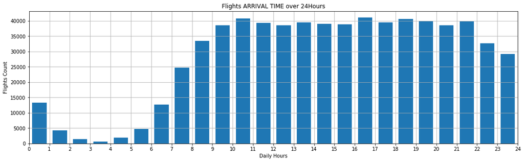

```python
#Flights ARRIVAL TIME over 24Hours
(flights['ARR_TIME']/100).hist(bins=24, rwidth=0.7);
plt.xlim(0,24);
plt.xticks(range(0,25,1));
plt.title("Flights ARRIVAL TIME over 24Hours");
plt.xlabel("Daily Hours");
plt.ylabel("Flights Count");
```

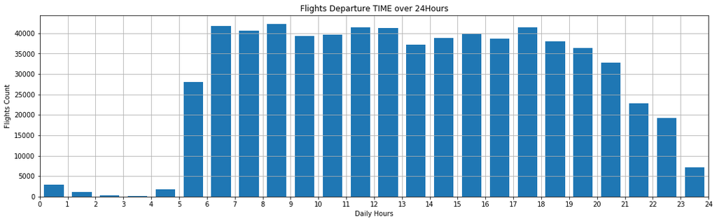

```python
#Flights Departure TIME over 24Hours
(flights['DEP_TIME']/100).hist(bins=24, rwidth=0.7);
plt.xlim(0,24);
plt.xticks(range(0,25,1));
plt.title("Flights Departure TIME over 24Hours");
plt.xlabel("Daily Hours");
plt.ylabel("Flights Count");
```

# Flights Actual Elapsed Time

```python
#Flights ACTUAL ELAPSED TIME
(flights['ACTUAL_ELAPSED_TIME']).describe()
```

```
count    672866.000000
mean        136.618781
std          73.161041
min          16.000000
25%          83.000000
50%         118.000000
75%         167.000000
max         708.000000
Name: ACTUAL_ELAPSED_TIME, dtype: float64
```

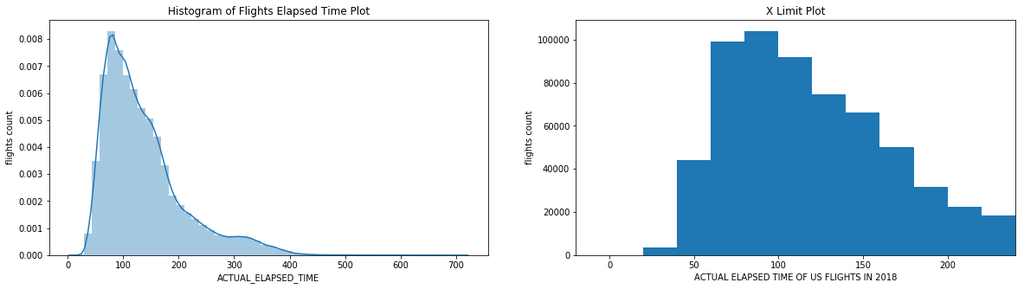

```python
plt.figure(figsize = [20, 5])

# histogram on left, example of too-large bin size
# 1 row, 2 cols, subplot 1
plt.subplot(1, 2, 1)
plt.title("Histogram of Flights Elapsed Time Plot")
sb.distplot(flights['ACTUAL_ELAPSED_TIME']);
plt.ylabel('flights count')

# histogram on right, example of too-small bin size
plt.subplot(1, 2, 2) # 1 row, 2 cols, subplot 2
plt.title("X Limit Plot")
bins = np.arange(0, flights['ACTUAL_ELAPSED_TIME'].max(), 20)
plt.hist(data = flights, x = 'ACTUAL_ELAPSED_TIME', bins = bins);
plt.xlabel('ACTUAL ELAPSED TIME OF US FLIGHTS IN 2018')
plt.ylabel('flights count')
plt.xlim(-20,240);
```

- we can find out that the most flights elapsed time in minutes normally distributed around 80-200 and there are outliers then we will use xlimit to elliminate the outliers that leads to right skwed.

# Distance

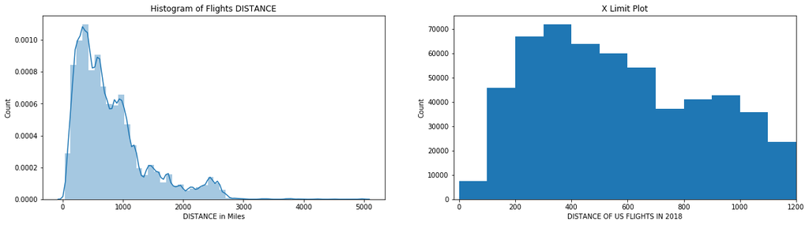

```python
plt.figure(figsize = [20, 5])

# histogram on left, example of too-large bin size
# 1 row, 2 cols, subplot 1
plt.subplot(1, 2, 1)
plt.title("Histogram of Flights DISTANCE")
sb.distplot(flights['DISTANCE']);
plt.xlabel('DISTANCE in Miles')
plt.ylabel('Count')

# histogram on right, example of too-small bin size
plt.subplot(1, 2, 2) # 1 row, 2 cols, subplot 2
plt.title("X Limit Plot")
bins = np.arange(0, flights['DISTANCE'].max()+100, 100)
plt.hist(data = flights, x = 'DISTANCE', bins = bins);
plt.xlabel('DISTANCE OF US FLIGHTS IN 2018')
plt.ylabel('Count')
plt.xlim(-20,1200);
```

- We find out Flights distance average is 630 miles and 75% quartile are 1036 miles and then we xlimit the plot to hide outliers.

```python
flights['DIVERTED'].value_counts()
```

```
0.0    672866
Name: DIVERTED, dtype: int64
```

- When we try to plot Diverted flights , we find it zero then no need to use this variable

### Discuss the distribution(s) of your variable(s) of interest. Were there any unusual points? Did you need to perform any transformations?

> As Numerical Variables, we can find out that the most flights elapsed time in minutes normally distributed around 80-200 and there are outliers then we will use xlimit to elliminate the outliers that leads to right skwed. Moreover, we find out Flights distance average is 630 miles and 75% quartile are 1036 miles and then we xlimit the plot to hide outliers. We provides bar charts for Origin & Destination Airports and US flight Carriers.

### Of the features you investigated, were there any unusual distributions? Did you perform any operations on the data to tidy, adjust, or change the form of the data? If so, why did you do this?

> We find out 'CANCELLED' flights, which are out of our interest then we clean out the selected dataset to include only Non-cancelled Flights. As we have 357 ORIGIN/DEST airports then we will graph the top 20 and then we will focus on top 6 Which are ATL, ORD, DFW, DEN, CLT, LAX Airports. Additionally, we choose Top5 OP_CARRIERS. Additionally, We can conclude that Southwest Airlines is the largest number of flights in 2018 by 18% of the total flights and we can explore that Delta Airlines, American Airlines, SkyWest Airlines, United Airlines took about 45% of flights. Therefore, we can see that Top 5 Airlines carriers took about 63% of US flights in 2018. Then we will focus on Top 5 in later analysis.

## Bivariate Exploration

# ARRIVAL DELAY & DEPARTURE DELAY Relationship

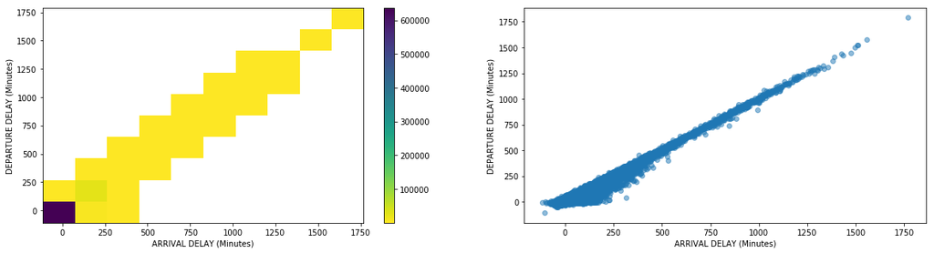

```python
# Scatter plot by MAtplotlib
#bins_x=np.arange(0.6,7+0.3,0.3)
#bins_y=np.arange(92,692+50,50)
# Resize figure to accommodate two plots
plt.figure(figsize = [20, 5])
plt.subplot(1, 2, 1)
#plt.scatter(data = flights, x='displ', y='co2', alpha=0.5);
plt.hist2d(data = flights, x='ARR_DELAY', y='DEP_DELAY', cmin=0.5, cmap='viridis_r');
plt.colorbar()
plt.xlabel('ARRIVAL DELAY (Minutes)')
plt.ylabel('DEPARTURE DELAY (Minutes)');
plt.subplot(1, 2, 2)
# Scatter plot by Seaborn library
sb.regplot(data = flights, x='ARR_DELAY', y='DEP_DELAY', fit_reg=False, truncate=True, x_jitter=0, scatter_kws={'alpha':1/2})
plt.xlabel('ARRIVAL DELAY (Minutes)')
plt.ylabel('DEPARTURE DELAY (Minutes)');
```

- We can find that linear relationship and postive correlation and also we can conclude that very small delays are the most affected for the majority of flights as we see the high density color(600,000 flights) around zero.

# DISTANCE , ARRIVAL_TIME, DEPARTURE_TIME Relationships

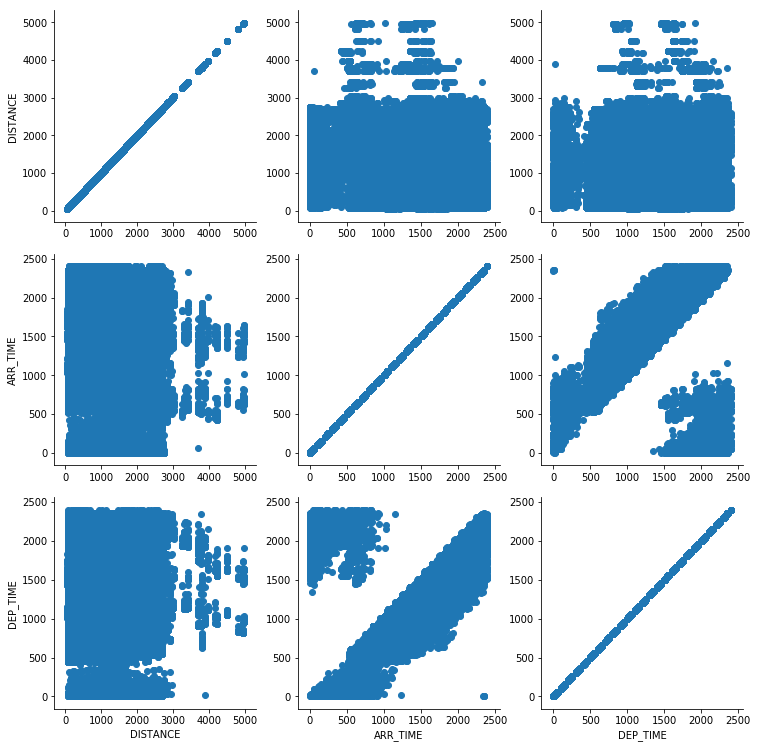

```python
cols = ['DISTANCE','ARR_TIME','DEP_TIME']
g = sb.PairGrid(flights[cols], size=3.5);
g.map(plt.scatter);
```

- We can't find clear evidence for strong relationship between Arrival time and Departrure time due to appearing large scatter out of the linear relationship. Additonally, Distance is totally not based on Arrival Time or Departure Time which reflects real logical meaning.

# Actual Elapsed Time and Distance Relationship

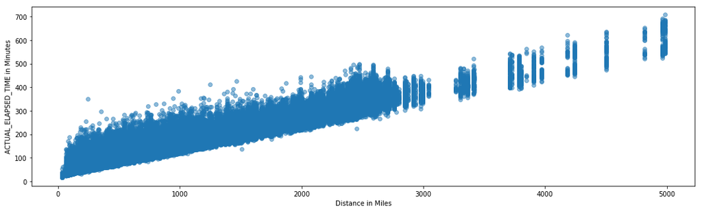

```python
# Scatter plot by MAtplotlib
plt.scatter(data = flights, x='DISTANCE', y='ACTUAL_ELAPSED_TIME', alpha=0.5);
plt.xlabel('Distance in Miles');
plt.ylabel('ACTUAL_ELAPSED_TIME in Minutes');
```

- We can findout Actual Elapsed Time of flight is proportional linearly with Distance in Miles

# ARRIVAL DELAY & TOP5 OP_CARRIER Relationship

```python
(flights.groupby(['OP_CARRIER']).count()['ARR_DELAY'])
```

```
OP_CARRIER
9E     22236
AA     85676
AS     23148
B6     28267
DL     89651
EV     18454
F9     11124
G4      8989
HA      7959
MQ     26934
NK     16633
OH     25511
OO     72602
UA     58164
VX      1624
WN    126667
YV     19901
YX     29326
Name: ARR_DELAY, dtype: int64
```

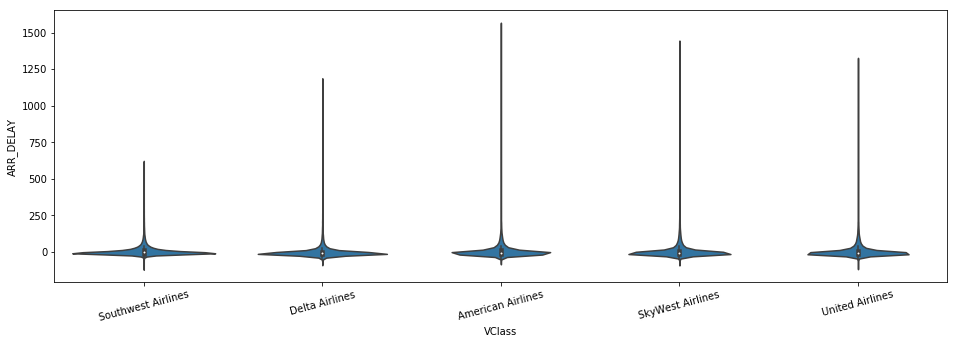

```python
plt.figure(figsize = [16, 5])
carrier_classes =['Southwest Airlines','Delta Airlines','American Airlines', 'SkyWest Airlines', 'United Airlines']
base_color = sb.color_palette()[0]
vclasses = pd.api.types.CategoricalDtype(ordered=True, categories=carrier_classes)
flights['VClass'] = flights['OP_CARRIER_NAME'].astype(vclasses);
ax1=sb.violinplot(data=flights, x='VClass', y='ARR_DELAY', color=base_color, innner='quartile');
plt.xticks(rotation=15);
plt.ylim(ax1.get_ylim());
```

- We can find out that delay centered around zero for Top5 carriers and we can see Southwest Airlines width is the largest due to it's the biggest OP_CARRIER in US in 2018